# MD5 Homework

Author

Ethan Murray

Published

October 15, 2023

```r
library(tidyverse)
```

```r
twitch_data <- read_csv("https://raw.githubusercontent.com/vaiseys/dav-course/main/Data/twitchdata-update.csv")
```

```r
library(janitor)
twitch_data <- clean_names(twitch_data)
colnames(twitch_data)
```

```
 [1] "channel"             "watch_time_minutes"  "stream_time_minutes"
 [4] "peak_viewers"        "average_viewers"     "followers"
 [7] "followers_gained"    "views_gained"        "partnered"
[10] "mature"              "language"
```

# Question 1

Illojuan has 4087 average viewers with 275,174 followers. CzechCloud has 978 average viewers with 180,668 followers. JohnPitterTV has 900 average viewers with 286,184 followers. TommyKayLIVE has 1124 average viewers with 127,770 followers. Zalae has 1351 average viewers with 170,668 followers.

```r
av_stats <- twitch_data %>%
  select(average_viewers, followers)
```

```r
summary(av_stats)
```

```
 average_viewers    followers
 Min.   :   235   Min.   :   3660
 1st Qu.:  1458   1st Qu.: 170546
 Median :  2425   Median : 318063
 Mean   :  4781   Mean   : 570054
 3rd Qu.:  4786   3rd Qu.: 624332
 Max.   :147643   Max.   :8938903
```

I thought it was interesting that the mean and 3 quartile of average viewers were almost the same.

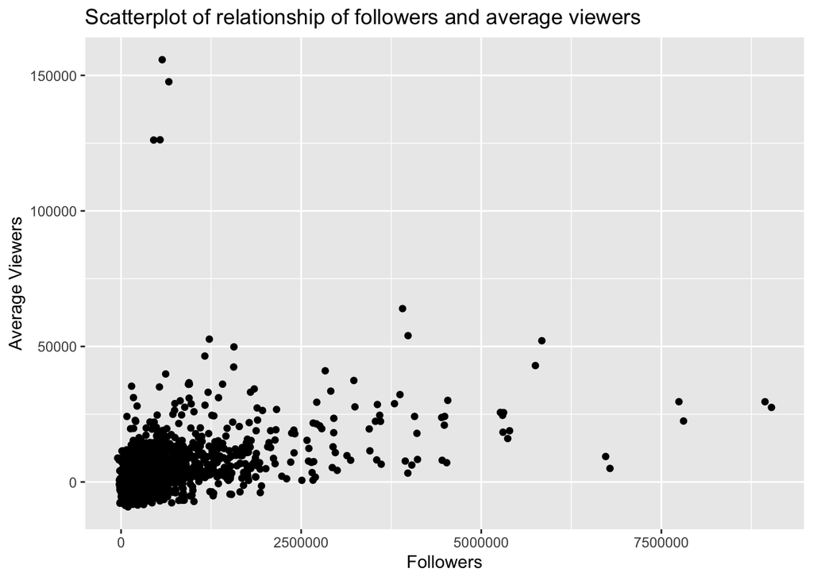

```r
ggplot(av_stats, aes(x = followers, y = average_viewers)) +
  geom_point() +
  geom_jitter(width = 100000, height = 10000) +
  labs(x = "Followers",
       y = "Average Viewers",
       title = "Scatterplot of relationship of followers and average viewers")
```

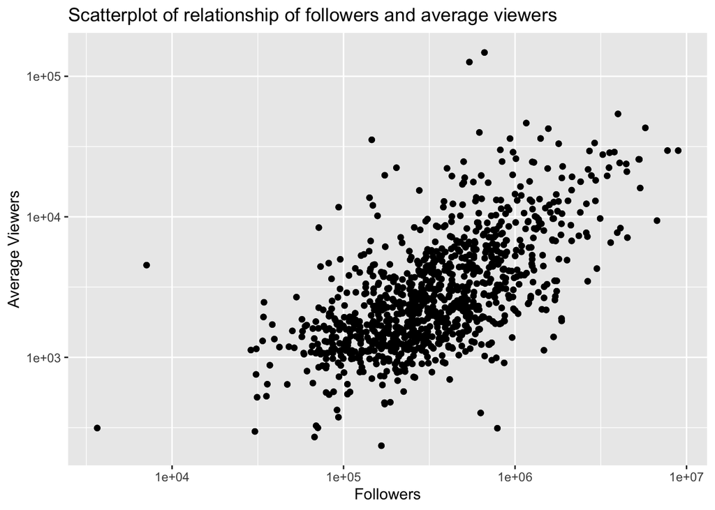

```r
ggplot(av_stats, aes(x = followers, y = average_viewers)) +
  geom_point() +
  scale_x_log10() +
  scale_y_log10() +
  geom_jitter() +
  labs(x = "Followers",
       y = "Average Viewers",
       title = "Scatterplot of relationship of followers and average viewers")
```

Now the relationship between followers and average viewers appears to be positive and is much easier to visualize.

```r
twitch_data <- twitch_data %>%
  mutate(log_viewers = log10(average_viewers),
         log_followers = log10(followers))
```

# Question 2

```r
fit1 <- lm(log_viewers ~ log_followers,
           data = twitch_data)
```

```r
library(broom)
```

```r
tidy(fit1)
```

| term | estimate | std.error | statistic | p.value |
| --- | --- | --- | --- | --- |
| (Intercept) | 0.1978359 | 0.1252767 | 1.579192 | 0.114609 |
| log_followers | 0.5884958 | 0.0225979 | 26.042115 | 0.000000 |

# Question 3

```r
library(broom)

pred_data <- augment(fit1)

# glimpse our new data
glimpse(pred_data)
```

```
Rows: 1,000
Columns: 8
$ log_viewers   <dbl> 4.442731, 4.408410, 4.040444, 3.887280, 4.471321, 4.6275…
$ log_followers <dbl> 6.511388, 6.725108, 6.247393, 6.596030, 6.951284, 6.1940…
$ .fitted       <dbl> 4.029761, 4.155534, 3.874400, 4.079572, 4.288638, 3.8430…
$ .resid        <dbl> 0.4129697, 0.2528757, 0.1660436, -0.1922928, 0.1826833, …
$ .hat          <dbl> 0.006194481, 0.008694557, 0.003782169, 0.007126066, 0.01…
$ .sigma        <dbl> 0.3085580, 0.3087321, 0.3087919, 0.3087764, 0.3087820, 0…
$ .cooksd       <dbl> 0.0056128779, 0.0029688873, 0.0005513456, 0.0014026033, …
$ .std.resid    <dbl> 1.3420109, 0.8227954, 0.5389316, -0.6251793, 0.5953620, …
```

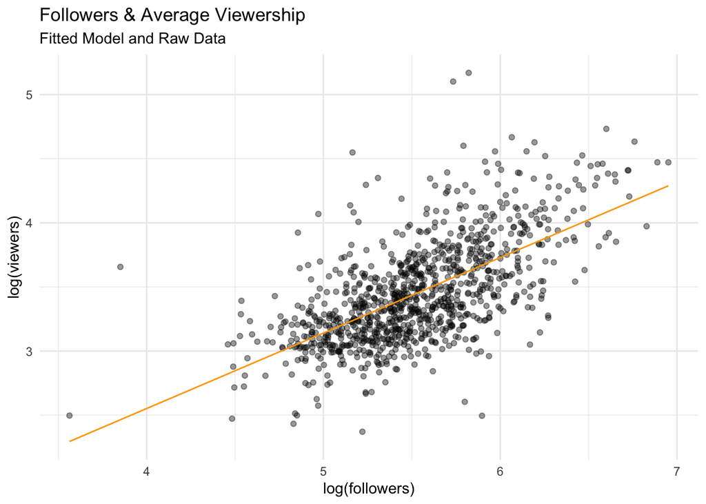

```r
pred_data %>%
  ggplot(aes(x = log_followers,
             y = log_viewers)) +
  geom_jitter(alpha = 0.4) +
  geom_line(aes(x = log_followers,
                y = .fitted),
            col = "orange") +
  theme_minimal() +
  labs(subtitle = "Fitted Model and Raw Data",
       title = "Followers & Average Viewership",
       x = "log(followers)",
       y = "log(viewers)")
```

The model appears to describe the relationship between the two variables well.. The line of best fit seems to provide a good visualization.

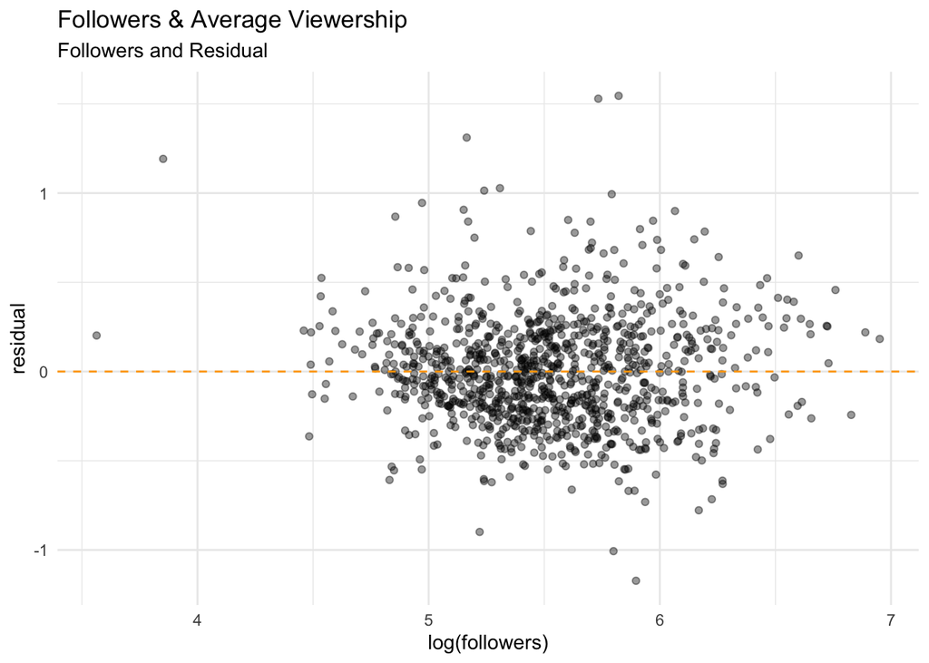

```r
pred_data %>%
  ggplot(aes(x = log_followers,
             y = .resid)) +
  geom_jitter(alpha = 0.4) +
  geom_hline(yintercept=0, linetype = "dashed", color = "orange") +
  theme_minimal() +
  labs(subtitle = "Followers and Residual",
       title = "Followers & Average Viewership",
       x = "log(followers)",
       y = "residual")
```

The bigger residuals reflect some of the streamers that our model displays poorly… We do.a relatively good job across the board, but obviously not perfect.

# Question 4

```r
lang_view <- twitch_data %>%
  select(average_viewers, language)
```

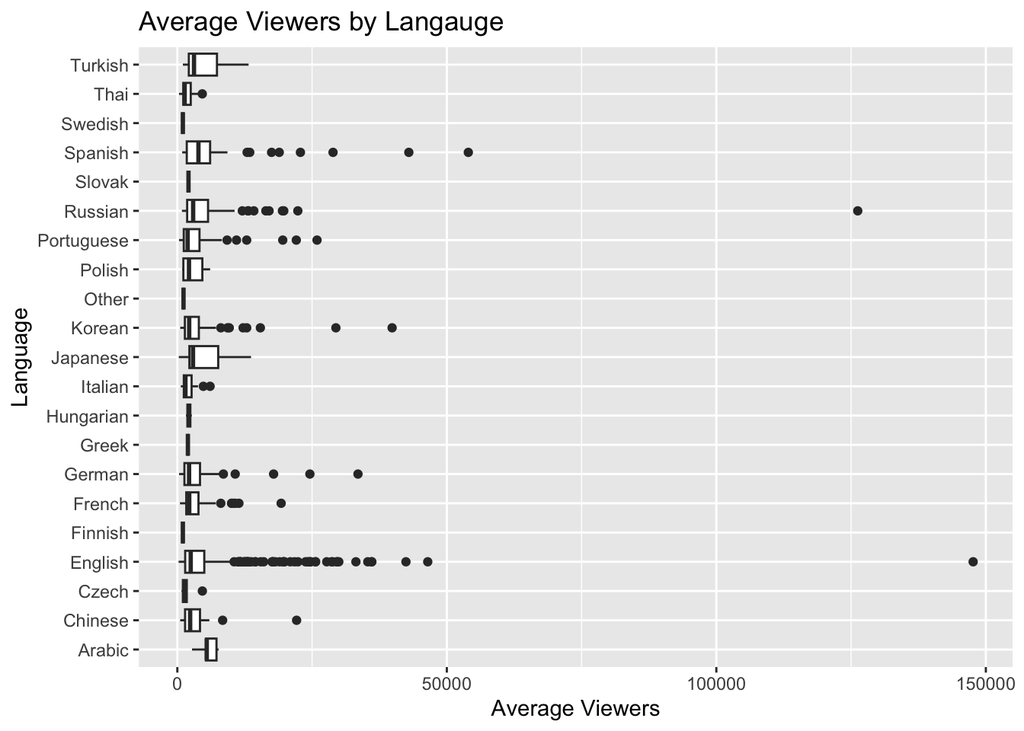

```r
ggplot(lang_view, aes(x = language, y = average_viewers)) +
  geom_boxplot() +
  coord_flip() +
  labs(x = "Language", y = "Average Viewers",
       title = "Average Viewers by Langauge")
```

# Question 5

```r
twitch_data <- twitch_data %>%
  mutate(language = as.factor(language),
         language = relevel(language, ref = "English"))
```

```r
views_lang <- lm(average_viewers ~ language, data = twitch_data)
```

```r
tidy(views_lang)
```

| term | estimate | std.error | statistic | p.value |
| --- | --- | --- | --- | --- |
| (Intercept) | 5112.8144 | 384.6448 | 13.2923016 | 0.0000000 |
| languageArabic | 569.3856 | 3807.7891 | 0.1495318 | 0.8811648 |
| languageChinese | -1688.0144 | 1593.6863 | -1.0591887 | 0.2897751 |
| languageCzech | -3285.1478 | 3479.5651 | -0.9441260 | 0.3453382 |
| languageFinnish | -4085.8144 | 8479.6510 | -0.4818376 | 0.6300290 |
| languageFrench | -1606.2841 | 1111.3828 | -1.4453023 | 0.1486930 |
| languageGerman | -834.6308 | 1269.7916 | -0.6572975 | 0.5111442 |
| languageGreek | -3151.8144 | 8479.6510 | -0.3716915 | 0.7102030 |
| languageHungarian | -2972.3144 | 6002.1843 | -0.4952055 | 0.6205662 |
| languageItalian | -2907.2850 | 2090.1971 | -1.3909143 | 0.1645675 |
| languageJapanese | -350.2144 | 2706.2159 | -0.1294111 | 0.8970589 |
| languageKorean | -1198.9313 | 1039.1605 | -1.1537499 | 0.2488843 |
| languageOther | -3963.8144 | 8479.6510 | -0.4674502 | 0.6402819 |
| languagePolish | -2207.5644 | 2475.4116 | -0.8917969 | 0.3727209 |
| languagePortuguese | -1311.8800 | 1150.7772 | -1.1399948 | 0.2545673 |
| languageRussian | 1481.4153 | 1057.1823 | 1.4012865 | 0.1614453 |
| languageSlovak | -3040.8144 | 8479.6510 | -0.3586014 | 0.7199706 |
| languageSpanish | 1336.8767 | 1096.9023 | 1.2187747 | 0.2232233 |
| languageSwedish | -4085.8144 | 8479.6510 | -0.4818376 | 0.6300290 |
| languageThai | -3101.4508 | 2582.8807 | -1.2007720 | 0.2301301 |
| languageTurkish | -351.9508 | 1846.5135 | -0.1906029 | 0.8488762 |

Your prediction seems to be holding true, however it is not the most popular compared to Arabic, Russian, Spanish as those countries have positive residuals.

# Question 6

```r
fit2 <- lm(average_viewers ~ language,
           data = twitch_data)
```

```r
tidy(fit2)
```

| term | estimate | std.error | statistic | p.value |
| --- | --- | --- | --- | --- |
| (Intercept) | 5112.8144 | 384.6448 | 13.2923016 | 0.0000000 |
| languageArabic | 569.3856 | 3807.7891 | 0.1495318 | 0.8811648 |
| languageChinese | -1688.0144 | 1593.6863 | -1.0591887 | 0.2897751 |
| languageCzech | -3285.1478 | 3479.5651 | -0.9441260 | 0.3453382 |
| languageFinnish | -4085.8144 | 8479.6510 | -0.4818376 | 0.6300290 |
| languageFrench | -1606.2841 | 1111.3828 | -1.4453023 | 0.1486930 |
| languageGerman | -834.6308 | 1269.7916 | -0.6572975 | 0.5111442 |
| languageGreek | -3151.8144 | 8479.6510 | -0.3716915 | 0.7102030 |
| languageHungarian | -2972.3144 | 6002.1843 | -0.4952055 | 0.6205662 |
| languageItalian | -2907.2850 | 2090.1971 | -1.3909143 | 0.1645675 |
| languageJapanese | -350.2144 | 2706.2159 | -0.1294111 | 0.8970589 |
| languageKorean | -1198.9313 | 1039.1605 | -1.1537499 | 0.2488843 |
| languageOther | -3963.8144 | 8479.6510 | -0.4674502 | 0.6402819 |
| languagePolish | -2207.5644 | 2475.4116 | -0.8917969 | 0.3727209 |
| languagePortuguese | -1311.8800 | 1150.7772 | -1.1399948 | 0.2545673 |
| languageRussian | 1481.4153 | 1057.1823 | 1.4012865 | 0.1614453 |
| languageSlovak | -3040.8144 | 8479.6510 | -0.3586014 | 0.7199706 |
| languageSpanish | 1336.8767 | 1096.9023 | 1.2187747 | 0.2232233 |
| languageSwedish | -4085.8144 | 8479.6510 | -0.4818376 | 0.6300290 |
| languageThai | -3101.4508 | 2582.8807 | -1.2007720 | 0.2301301 |
| languageTurkish | -351.9508 | 1846.5135 | -0.1906029 | 0.8488762 |

```r
new_data <- augment(fit2)
```

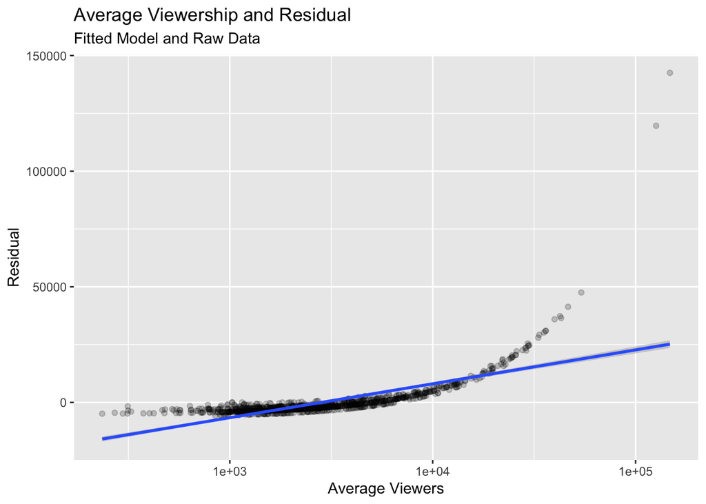

```r
new_data %>% ggplot(aes(x = average_viewers, y = .resid)) + geom_jitter(alpha = 0.2) + geom_smooth(method = lm) + scale_x_log10() + labs(subtitle = "Fitted Model and Raw Data", title = "Average Viewership and Residual", x = "Average Viewers", y = "Residual")
```

The clear outliers here and the points our model missed were dota2ti and dota2ti_ru… This streamer has both an English and Russian stream which accounts for the two points seen as outliers on the above graph.